# Data 607 - Project 2 - Data Transformation

William Jasmine

2022-10-7

# Introduction

The data is also stored in the following [Github location](https://github.com/williamzjasmine/CUNY_SPS_DS/tree/master/DATA_607/Projects/Project2/unclean_data).

# Import Data

The following cells import each of the `.csv` files listed above from the specified github location.

```r
csv_data = getURL("https://raw.githubusercontent.com/williamzjasmine/CUNY_SPS_DS/master/DATA_607/Projects/Project2/unclean_data/unclean_GDP_data.csv")
gdp_df = read.csv(text = csv_data)
head(gdp_df)
```

```
##               ï..Country.Name Country.Code    Indicator.Name Indicator.Code
## 1                       Aruba          ABW GDP (current US$) NY.GDP.MKTP.CD
## 2 Africa Eastern and Southern          AFE GDP (current US$) NY.GDP.MKTP.CD
## 3                 Afghanistan          AFG GDP (current US$) NY.GDP.MKTP.CD
## 4  Africa Western and Central          AFW GDP (current US$) NY.GDP.MKTP.CD
## 5                      Angola          AGO GDP (current US$) NY.GDP.MKTP.CD
## 6                     Albania          ALB GDP (current US$) NY.GDP.MKTP.CD
##         X1960       X1961       X1962       X1963       X1964       X1965
## 1          NA          NA          NA          NA          NA          NA
## 2 21290586003 21808473825 23707015394 28210036878 26118787467 29682172751
## 3   537777811   548888896   546666678   751111191   800000044  1006666638
## 4 10404135069 11127894641 11943187848 12676330765 13838369295 14862225760
## 5          NA          NA          NA          NA          NA          NA
## 6          NA          NA          NA          NA          NA          NA
##         X1966       X1967       X1968       X1969       X1970       X1971
```

[output cut: 69 more lines]

```r
csv_data = getURL("https://raw.githubusercontent.com/williamzjasmine/CUNY_SPS_DS/master/DATA_607/Projects/Project2/unclean_data/unclean_student_data.csv")

student_df = read.csv(text = csv_data)
head(student_df)
```

```
##   id   name phone sex.and.age test.number term.1 term.2 term.3
## 1  1   Mike   134        m_12      test 1     76     84     87
## 2  2  Linda   270        f_13      test 1     88     90     73
## 3  3    Sam   210        m_11      test 1     78     74     80
## 4  4 Esther   617        f_12      test 1     68     75     74
## 5  5   Mary   114        f_14      test 1     65     67     64
## 6  6    Dan   114        f_14      test 1     81     67     90
```

```r
csv_data = getURL("https://raw.githubusercontent.com/williamzjasmine/CUNY_SPS_DS/master/DATA_607/Projects/Project2/unclean_data/unclean_atmosphere_data.csv")

atmos_df = read.csv(text = csv_data)
head(atmos_df)
```

```
##   X  Altitude X.Air.press   X.ppO2    X.Alv.pO2    X...sat.O2 X.Alv.pCO2
## 1 1      Ft/m        mmHg  Air=21%  mmHg on air  >90% desired   >35 best
## 2 2 Sea level         760      159          104            97         40
## 3 3    10k/3k         523      110           67            90         36
## 4 4  20k/6.1k         349       73           40            73         24
## 5 5  30k/9.1k         226       47           18            24         24
## 6 6   40k/12k         141       29          NaN           NaN        NaN
##   X.Alv.pO2.with.O2.100. X...sat.O2_1 X.Alv.pCO2_1
## 1                     NA      100% O2      100% O2
## 2                    673          100           40
## 3                    436          100           40
## 4                    262          100           40
## 5                    139           99           40
## 6                     58           84           36
```

Looking above, it is clear that each of the `.csv` files were successfully imported, and the `head` of each is printed above. The three files have now been turned into three R dataframes: `gdp_df`, `student_df`, and `atmos_df`. The following sections will separately clean and analyze each of these dataframes.

# GDP Dataset

## Cleaning the Data

The first step is to clean the column names so that its easier to access the required data for each subsequent cleaning step. The column names have a number of issues, which are listed below along with how they can be fixed:

1. The year columns all start with a `X.` This can be fixed by using a `str_replace_all`.
2. The categorical variable columns all have `.` characters (which replaced the spaces in the original `.csv` file). This can be fixed by using a `str_replace_all`.
3. The first column name `ï..Country.Name` has a special character and can be fixed by just renaming the column completely to `country_name`.
4. The column names include capital letters, which can be fixed using the `tolower()` function.

Each of these fixes is performed in the code chunk below, and the commented numbers correspond to the where each of the above steps is performed.

```r
new_col_names <-
  colnames(gdp_df) %>% #1
    str_replace_all("X", '') %>% #2
      str_replace_all('\\.', '_') %>% #3
        tolower() #4
new_col_names[1] <- 'country_name'

colnames(gdp_df) <- new_col_names
head(gdp_df, 1)
```

```
##   country_name country_code    indicator_name indicator_code 1960 1961 1962
## 1        Aruba          ABW GDP (current US$) NY.GDP.MKTP.CD   NA   NA   NA
##   1963 1964 1965 1966 1967 1968 1969 1970 1971 1972 1973 1974 1975 1976 1977
## 1   NA   NA   NA   NA   NA   NA   NA   NA   NA   NA   NA   NA   NA   NA   NA
##   1978 1979 1980 1981 1982 1983 1984 1985      1986      1987      1988
## 1   NA   NA   NA   NA   NA   NA   NA   NA 405586592 487709497 596648045
##        1989      1990      1991      1992       1993       1994       1995
## 1 695530726 764804469 872067039 958659218 1083240223 1245810056 1320670391
##         1996       1997       1998       1999       2000       2001       2002
## 1 1379888268 1531843575 1665363128 1722905028 1873184358 1896648045 1962011173
##         2003       2004       2005       2006       2007       2008       2009
## 1 2044134078 2254748603 2359776536 2469832402 2677653631 2843016760 2553631285
##         2010       2011       2012       2013       2014       2015       2016
## 1 2453631285 2637988827 2615083799 2727932961 2791061453 2963128492 2983798883
##         2017       2018       2019       2020 2021
## 1 3092178771 3202234637 3310055866 2496648045   NA
```

As is clear in the output above, the column names are all fixed.

Next step is to convert the numerous year columns into a single field (as opposed to each year having its own column). Completing this step means that the data will be in a more desirable long format, and can be easily accomplished using the `pivot_longer` function. This is done in the code chunk below:

```r
cols_to_keep <- c('country_name', 'country_code', 'indicator_name', 'indicator_code')
gdp_df <- pivot_longer(gdp_df,
                   cols = !all_of(cols_to_keep),
                   names_to = 'year',
                   values_to = 'gdp')
head(gdp_df)
```

```
## # A tibble: 6 × 6
##   country_name country_code indicator_name    indicator_code year    gdp
##   <chr>        <chr>        <chr>             <chr>          <chr> <dbl>
## 1 Aruba        ABW          GDP (current US$) NY.GDP.MKTP.CD 1960     NA
## 2 Aruba        ABW          GDP (current US$) NY.GDP.MKTP.CD 1961     NA
## 3 Aruba        ABW          GDP (current US$) NY.GDP.MKTP.CD 1962     NA
## 4 Aruba        ABW          GDP (current US$) NY.GDP.MKTP.CD 1963     NA
## 5 Aruba        ABW          GDP (current US$) NY.GDP.MKTP.CD 1964     NA
## 6 Aruba        ABW          GDP (current US$) NY.GDP.MKTP.CD 1965     NA
```

The `pivot_longer` specifies in the `names_to` column that the year columns are to be melted into a single field called `year`. The values in the cells are then also melted into a single field called `gdp`.

While the data now has the desired structure, it is clear from the output that there are a number of `NA` entries, representing years in which the GDP was not recorded for a given country. While it might make sense to replace these `NA` values with a string like `"not recorded"`, we are unable to do so since that would mean two different datatypes would be stored in the same column, which is not possible.

There is however one last data cleaning step that is possible: the cells below print the unique values present in both the `indicator_name` and `indicator_code` columns:

```r
print(unique(gdp_df$indicator_name))
```

```
## [1] "GDP (current US$)"
```

```r
print(unique(gdp_df$indicator_code))
```

```
## [1] "NY.GDP.MKTP.CD"
```

As it is clear in the output above, each of the columns only one value, telling us that all of the measurements are GDP values measured in US dollars. Since all the measurements in the `gdp` column are of the same type and unit, these columns provide no additional information. As such, they are removed in the cell below.

```r
gdp_df <-
  gdp_df %>% select(country_name, country_code, year, gdp)
head(gdp_df)
```

```
## # A tibble: 6 × 4
##   country_name country_code year    gdp
##   <chr>        <chr>        <chr> <dbl>
## 1 Aruba        ABW          1960     NA
## 2 Aruba        ABW          1961     NA
## 3 Aruba        ABW          1962     NA
## 4 Aruba        ABW          1963     NA
## 5 Aruba        ABW          1964     NA
## 6 Aruba        ABW          1965     NA
```

The data frame above is now in its final form, and is ready to be analyzed.

## Analysis

One possible research question we can now answer with the cleaned data is to determine the global trend in GDP year over year (both as total dollar amount and percent change).

The first step in doing so is to aggregate the global GDP by year for all countries. This is done below using a `groupby` and `summarise` function:

```r
global_gdp_df <-
  gdp_df %>%
    filter(!is.na(gdp)) %>%
      group_by(year) %>%
        summarise(global_gdp = sum(gdp))
head(global_gdp_df)
```

```
## # A tibble: 6 × 2
##   year  global_gdp
##   <chr>      <dbl>
## 1 1960     9.50e12
## 2 1961     9.76e12
## 3 1962     1.04e13
## 4 1963     1.12e13
## 5 1964     1.23e13
## 6 1965     1.35e13
```

The output above shows the newly created`global_gdp_df` dataframe, which contains the global GDP each year in USD. The cell below adds to that dataframe the percent change in global GDP using the `lag` window function:

```r
global_gdp_df <-
  global_gdp_df %>%
    mutate(percent_change = (global_gdp - lag(global_gdp)) / lag(global_gdp))
head(global_gdp_df)
```

```
## # A tibble: 6 × 3
##   year  global_gdp percent_change
##   <chr>      <dbl>          <dbl>
## 1 1960     9.50e12        NA
## 2 1961     9.76e12         0.0269
## 3 1962     1.04e13         0.0660
## 4 1963     1.12e13         0.0785
## 5 1964     1.23e13         0.0983
## 6 1965     1.35e13         0.0969
```

The code cell below checks to make sure that the calculation done above is correct but finding the percent change in global GDP from 1960 to 1961 and comparing it to the analogous `percent_change` value in the dataframe:

```r
tmp = global_gdp_df$global_gdp
(tmp[2] - tmp[1]) / tmp[1] == global_gdp_df$percent_change[2]
```

```
## [1] TRUE
```

The `TRUE` output above means that the percent change calculation worked correctly and that these values can now be plotted:

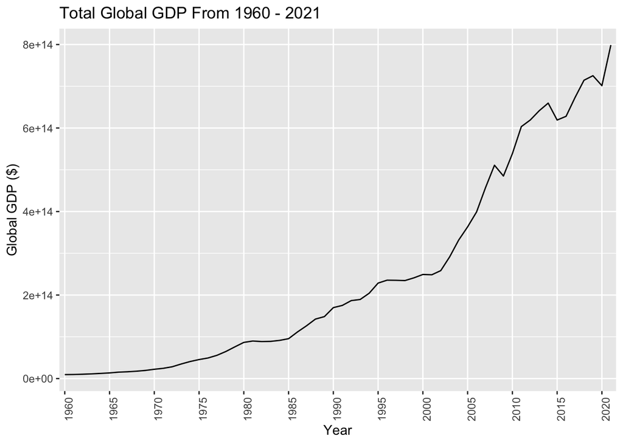

```r
ggplot(data = global_gdp_df) +
  geom_line(mapping = aes(x = year, y = global_gdp, group=1)) +
  labs(
    x = "Year",
    y = 'Global GDP ($)',
    title = "Total Global GDP From 1960 - 2021",
  ) +
  scale_x_discrete(breaks=seq(1960, 2020, 5)) +
  theme(axis.text.x = element_text(angle = 90))
```

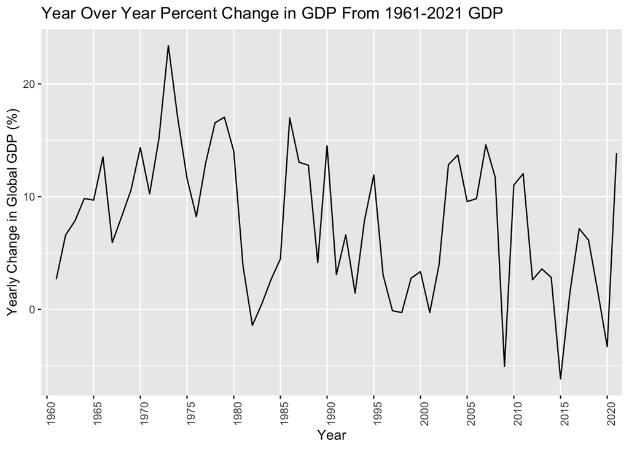

```r
ggplot(data = global_gdp_df) +
  geom_line(mapping = aes(x = year, y = percent_change * 100, group=1)) +
  labs(
    x = "Year",
    y = 'Yearly Change in Global GDP (%)',
    title = "Year Over Year Percent Change in GDP From 1961-2021 GDP",
  ) +
  scale_x_discrete(breaks=seq(1960, 2020, 5)) +
  theme(axis.text.x = element_text(angle = 90))
```

In the above plots, we can make pinpoint the location of important global economic events. Most recently, we see the dips in global GDP (both value and percentage) in 2009 and 2020, due to the 2008 recession and Covid-19, respectively.

# Student Dataset

## Data Cleaning

The first step in cleaning the `student_df` dataframe is, once again, to clean the column names. For this dataframe, the only issue with the column names is that they contain `.` characters. The are removed below using the `str_replace_all` function.

```r
new_col_names <-
  colnames(student_df) %>%
    str_replace_all("\\.", '_')

colnames(student_df) <- new_col_names
head(student_df, 1)
```

```
##   id name phone sex_and_age test_number term_1 term_2 term_3
## 1  1 Mike   134        m_12      test 1     76     84     87
```

The next data cleaning steps are to:

1. Transform the `sex_and_age` column into two separate columns, one containing the student’s gender, and the other containing their age.
2. Remove the word “test” from the values in the `test_number` field, given that we already know the numbers correspond to different tests thanks to the column name.

Both of these steps are completed below using a single `mutate` in tandem with the `str_extract` function:

```r
student_df <-
  student_df %>%
    mutate(gender = str_extract(sex_and_age, '(m|f)'),
           age = str_extract(sex_and_age, '\\d\\d'),
           test_no = strtoi(str_extract(test_number, '\\d'))) %>%
      select(-sex_and_age, -test_number)

head(student_df)
```

```
##   id   name phone term_1 term_2 term_3 gender age test_no
## 1  1   Mike   134     76     84     87      m  12       1
## 2  2  Linda   270     88     90     73      f  13       1
## 3  3    Sam   210     78     74     80      m  11       1
## 4  4 Esther   617     68     75     74      f  12       1
## 5  5   Mary   114     65     67     64      f  14       1
## 6  6    Dan   114     81     67     90      f  14       1
```

The final step in this case, is to use the `pivot_longer` function to melt the “term” fields into a single column. This is done in the code chunk below:

```r
cols_to_melt <- c('term_1', 'term_2', 'term_3')
student_df <- pivot_longer(student_df,
                   cols = all_of(cols_to_melt),
                   names_to = 'term',
                   values_to = 'test_score')
head(student_df)
```

```
## # A tibble: 6 × 8
##      id name  phone gender age   test_no term   test_score
##   <int> <chr> <int> <chr>  <chr>   <int> <chr>       <int>
## 1     1 Mike    134 m      12          1 term_1         76
## 2     1 Mike    134 m      12          1 term_2         84
## 3     1 Mike    134 m      12          1 term_3         87
## 4     2 Linda   270 f      13          1 term_1         88
## 5     2 Linda   270 f      13          1 term_2         90
## 6     2 Linda   270 f      13          1 term_3         73
```

Like with the original `test_number` column, we can remove the extraneous word “term” from the values in the `term` column:

```r
student_df$term <- str_extract(student_df$term, '\\d')
head(student_df)
```

```
## # A tibble: 6 × 8
##      id name  phone gender age   test_no term  test_score
##   <int> <chr> <int> <chr>  <chr>   <int> <chr>      <int>
## 1     1 Mike    134 m      12          1 1             76
## 2     1 Mike    134 m      12          1 2             84
## 3     1 Mike    134 m      12          1 3             87
## 4     2 Linda   270 f      13          1 1             88
## 5     2 Linda   270 f      13          1 2             90
## 6     2 Linda   270 f      13          1 3             73
```

The output represents the final dataframe, which is now ready to be analyzed.

## Analysis

Given that the cleaned `student_df` dataframe contains information regarding students test scores for a number of different school terms, an interesting research task might be to check the normality of the distribution of the student’s final letter grades after each term.

To do this, we first need to figure out each student’s average test score after each term. This is done below using a `group_by` and `summarise` function:

```r
avg_test_scores <-
  student_df %>%
    group_by(name, term) %>%
      summarise(avg_test_score = mean(test_score))
head(avg_test_scores)
```

```
## # A tibble: 6 × 3
## # Groups:   name [2]
##   name   term  avg_test_score
##   <chr>  <chr>          <dbl>
## 1 Dan    1               84.5
## 2 Dan    2               74
## 3 Dan    3               89.5
## 4 Esther 1               69
## 5 Esther 2               75
## 6 Esther 3               76
```

The following code uses an `if` statement to categorize the student’s final grades as letter grades:

```r
avg_test_scores <-
  avg_test_scores %>%
    mutate(
    letter_grade =
      ifelse(avg_test_score >= 90, 'A',
      ifelse(avg_test_score >= 80, 'B',
      ifelse(avg_test_score >= 70, 'C',
      ifelse(avg_test_score >= 65, 'D',
      'F')))),
    hist_grade =
      ifelse(avg_test_score >= 90, 2,
      ifelse(avg_test_score >= 80, 1,
      ifelse(avg_test_score >= 70, 0,
      ifelse(avg_test_score >= 65, -1,
      -2))))
    )

table(avg_test_scores$letter_grade)
```

```
##
##  A  B  C  D  F
##  3 11  8  5  3
```

The output above prints the distributions of letter grades from all students after each term, but in order to get a better idea of whether or not the data is normal it is plotted below along with a normal distribution:

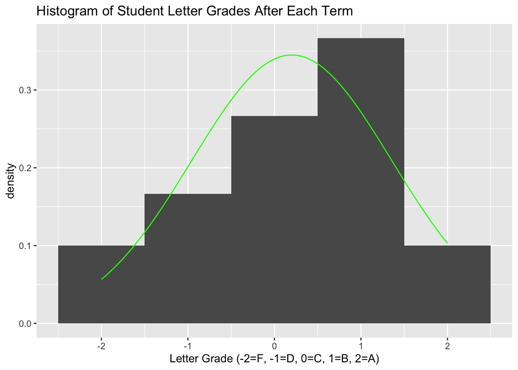

```r
ggplot(data = avg_test_scores, aes(x = hist_grade)) +
  geom_blank() +
  geom_histogram(aes(y = ..density..), bins=5) +
  stat_function(fun = dnorm,
                args = c(mean = mean(avg_test_scores$hist_grade),
                         sd = sd(avg_test_scores$hist_grade)),
                col = "green") +
  labs(
    x = "Letter Grade (-2=F, -1=D, 0=C, 1=B, 2=A)",
    title = "Histogram of Student Letter Grades After Each Term",
  )
```

# Atmosphere Dataset

## Cleaning Data

The cell below gives another look at the unclean `atmoshpere_df` dataframe:

```r
head(atmos_df)
```

```
##   X  Altitude X.Air.press   X.ppO2    X.Alv.pO2    X...sat.O2 X.Alv.pCO2
## 1 1      Ft/m        mmHg  Air=21%  mmHg on air  >90% desired   >35 best
## 2 2 Sea level         760      159          104            97         40
## 3 3    10k/3k         523      110           67            90         36
## 4 4  20k/6.1k         349       73           40            73         24
## 5 5  30k/9.1k         226       47           18            24         24
## 6 6   40k/12k         141       29          NaN           NaN        NaN
##   X.Alv.pO2.with.O2.100. X...sat.O2_1 X.Alv.pCO2_1
## 1                     NA      100% O2      100% O2
## 2                    673          100           40
## 3                    436          100           40
## 4                    262          100           40
## 5                    139           99           40
## 6                     58           84           36
```

The first step in this case is to remove the extraneous `X` index column of the dataframe, as R automatically indexes rows of a datafrmae itself. This is done in the cell below:

```r
atmos_df <- atmos_df %>%
  select(-X)
head(atmos_df)
```

```
##    Altitude X.Air.press   X.ppO2    X.Alv.pO2    X...sat.O2 X.Alv.pCO2
## 1      Ft/m        mmHg  Air=21%  mmHg on air  >90% desired   >35 best
## 2 Sea level         760      159          104            97         40
## 3    10k/3k         523      110           67            90         36
## 4  20k/6.1k         349       73           40            73         24
## 5  30k/9.1k         226       47           18            24         24
## 6   40k/12k         141       29          NaN           NaN        NaN
##   X.Alv.pO2.with.O2.100. X...sat.O2_1 X.Alv.pCO2_1
## 1                     NA      100% O2      100% O2
## 2                    673          100           40
## 3                    436          100           40
## 4                    262          100           40
## 5                    139           99           40
## 6                     58           84           36
```

Our next step is to once again clean the column names of the `atmos_df` dataframe. There are a number of cleaning steps that need to be performed, each of which is listed below:

1. Remove the `X` characters from the column names.
2. Remove the `.` characters in front of the column names.
3. Replace the `.` characters inside the column names with `_` characters.

Each of these steps is performed below, and is labeled via a comment in the code:

```r
new_col_names <-
  colnames(atmos_df) %>%
    str_replace_all('X', "") %>% #1
      str_replace_all('^\\.*', '') %>% #2
        str_replace_all('\\.', '_') %>% #3
          tolower()

colnames(atmos_df) <- new_col_names
head(atmos_df)
```

```
##    altitude air_press     ppo2      alv_po2        sat_o2  alv_pco2
## 1      Ft/m      mmHg  Air=21%  mmHg on air  >90% desired  >35 best
## 2 Sea level       760      159          104            97        40
## 3    10k/3k       523      110           67            90        36
## 4  20k/6.1k       349       73           40            73        24
## 5  30k/9.1k       226       47           18            24        24
## 6   40k/12k       141       29          NaN           NaN       NaN
##   alv_po2_with_o2_100_ sat_o2_1 alv_pco2_1
## 1                   NA  100% O2    100% O2
## 2                  673      100         40
## 3                  436      100         40
## 4                  262      100         40
## 5                  139       99         40
## 6                   58       84         36
```

The next data cleaning step involves removing the first row of the dataframe: inspecting this row in the output above reveals that this row just contains notes on what the measurements are in each column. Because it doesn’t have any measurements itself, it should be removed. However, in order for the information in the row to still be accessible, it is saved in the `field_info` dataframe before it is deleted from `atmos_df`.

```r
field_info <- atmos_df[1,]
atmos_df <- atmos_df[-1,]
rownames(atmos_df) <- NULL
head(atmos_df)
```

```
##    altitude air_press ppo2 alv_po2 sat_o2 alv_pco2 alv_po2_with_o2_100_
## 1 Sea level       760  159     104     97       40                  673
## 2    10k/3k       523  110      67     90       36                  436
## 3  20k/6.1k       349   73      40     73       24                  262
## 4  30k/9.1k       226   47      18     24       24                  139
## 5   40k/12k       141   29     NaN    NaN      NaN                   58
## 6 50k/15.2k        87   18     NaN    NaN      NaN                   16
##   sat_o2_1 alv_pco2_1
## 1      100         40
## 2      100         40
## 3      100         40
## 4       99         40
## 5       84         36
## 6       15         24
```

The next step is to clean the altitude column, as this represents the single “categorical” variable we will use for the final dataframe. Upon inspection of the values in this column, there are a number of data cleaning steps that need to be performed:

1. The “Sea Level” value should be replaced with 0.
2. The feet and meter measurements need to be separated into their own separate columns.
3. Each value needs to be multiplied by 1,000, as indicated by the `k` characters.

Steps 2 and 3 are performed below using a `mutate` in tandem with a combination of `str_extract` and `str_replace` functions.

```r
atmos_df <-
  atmos_df %>%
    mutate(
        altitude_ft = strtoi(str_extract(altitude, '\\d\\d')) * 1000,
        altitude_m = str_extract(altitude, '\\/(\\d\\d?\\.?\\d?k)') %>%
          str_replace('k', '') %>%
            str_replace('\\/', '') %>%
              as.numeric() * 1000
    )

atmos_df <-
  cbind(
    select(atmos_df, altitude_ft, altitude_m),
    select(atmos_df, -altitude_ft, -altitude_m)
  )
head(atmos_df)
```

```
##   altitude_ft altitude_m  altitude air_press ppo2 alv_po2 sat_o2 alv_pco2
## 1          NA         NA Sea level       760  159     104     97       40
## 2       10000       3000    10k/3k       523  110      67     90       36
## 3       20000       6100  20k/6.1k       349   73      40     73       24
## 4       30000       9100  30k/9.1k       226   47      18     24       24
## 5       40000      12000   40k/12k       141   29     NaN    NaN      NaN
## 6       50000      15200 50k/15.2k        87   18     NaN    NaN      NaN
##   alv_po2_with_o2_100_ sat_o2_1 alv_pco2_1
## 1                  673      100         40
## 2                  436      100         40
## 3                  262      100         40
## 4                  139       99         40
## 5                   58       84         36
## 6                   16       15         24
```

We can see now that the `altitude_ft` and `altitude_m` fields have been created, and that they are now numeric fields as opposed to a single character field. Finally, the cell below uses the `replace_na` function to fill the single `NA` value in these columns with 0 (sea level elevation). It also removes the old `altitude` column, as it is no longer required.

```r
atmos_df$altitude_ft <- replace_na(atmos_df$altitude_ft, 0)
atmos_df$altitude_m <-replace_na(atmos_df$altitude_m, 0)
atmos_df <- select(atmos_df, -altitude)

atmos_df
```

```
##   altitude_ft altitude_m air_press ppo2 alv_po2 sat_o2 alv_pco2
## 1           0          0       760  159     104     97       40
## 2       10000       3000       523  110      67     90       36
## 3       20000       6100       349   73      40     73       24
## 4       30000       9100       226   47      18     24       24
## 5       40000      12000       141   29     NaN    NaN      NaN
## 6       50000      15200        87   18     NaN    NaN      NaN
##   alv_po2_with_o2_100_ sat_o2_1 alv_pco2_1
## 1                  673      100         40
## 2                  436      100         40
## 3                  262      100         40
## 4                  139       99         40
## 5                   58       84         36
## 6                   16       15         24
```

The next step is to change the data types of the remaining character columns, as they are all actually numerical measurement values. While all the values seen above are technically integers, the types of measurements being taken are taken on a continuous scale. As such, these fields are all converted to a numeric type so that any future measurements that might be added will be able to have decimal point values.

```r
atmos_df <-atmos_df %>%
  mutate_if(is.character, as.numeric) %>%
    mutate_if(is.integer, as.numeric)
head(atmos_df)
```

```
##   altitude_ft altitude_m air_press ppo2 alv_po2 sat_o2 alv_pco2
## 1           0          0       760  159     104     97       40
## 2       10000       3000       523  110      67     90       36
## 3       20000       6100       349   73      40     73       24
## 4       30000       9100       226   47      18     24       24
## 5       40000      12000       141   29     NaN    NaN      NaN
## 6       50000      15200        87   18     NaN    NaN      NaN
##   alv_po2_with_o2_100_ sat_o2_1 alv_pco2_1
## 1                  673      100         40
## 2                  436      100         40
## 3                  262      100         40
## 4                  139       99         40
## 5                   58       84         36
## 6                   16       15         24
```

Now that all the measurement columns have been converted to numeric fields, we can complete the final data cleaning step: converting the dataframe into a long format. In this case, the altitude values represent our “categorical” fields, as each atmospheric measurement was taken at every one of the included heights. The remaining measurement fields are then all melted into a single `measurement_type` field, with the actual measurements being stored in a `measurement` column. This is done below using the `pivot_longer` function:

```r
atmos_df <-
  pivot_longer(atmos_df, cols = !c(altitude_ft, altitude_m),
               names_to = 'measurement_type', values_to = 'measurement')

head(atmos_df)
```

```
## # A tibble: 6 × 4
##   altitude_ft altitude_m measurement_type     measurement
##         <dbl>      <dbl> <chr>                      <dbl>
## 1           0          0 air_press                    760
## 2           0          0 ppo2                         159
## 3           0          0 alv_po2                      104
## 4           0          0 sat_o2                        97
## 5           0          0 alv_pco2                      40
## 6           0          0 alv_po2_with_o2_100_         673
```

The output above represents our final dataframe. The benefit of having the data in this format is that now different measurements can now be easily added as rows. This includes measurements of fields that already exist in the `measurement_type` column, but it is also easy to add a completely new measurement type without having to create a completely new field.

## Analysis

One interesting research question for this data might be to see the correlation between air pressure and the air pressure due to oxygen (`ppo2` in the dataframe) as we go higher and higher up into the sky. To do this, we can look at a scatter plot of this data. First, the cell below gathers the required information:

```r
plt_df <-
  atmos_df %>%
      filter(measurement_type == 'air_press' | measurement_type == 'ppo2') %>%
        pivot_wider(names_from = measurement_type, values_from = measurement)

head(plt_df)
```

```
## # A tibble: 6 × 4
##   altitude_ft altitude_m air_press  ppo2
##         <dbl>      <dbl>     <dbl> <dbl>
## 1           0          0       760   159
## 2       10000       3000       523   110
## 3       20000       6100       349    73
## 4       30000       9100       226    47
## 5       40000      12000       141    29
## 6       50000      15200        87    18
```

Next, the cell below plots air pressure as a function of oxygen concentration:

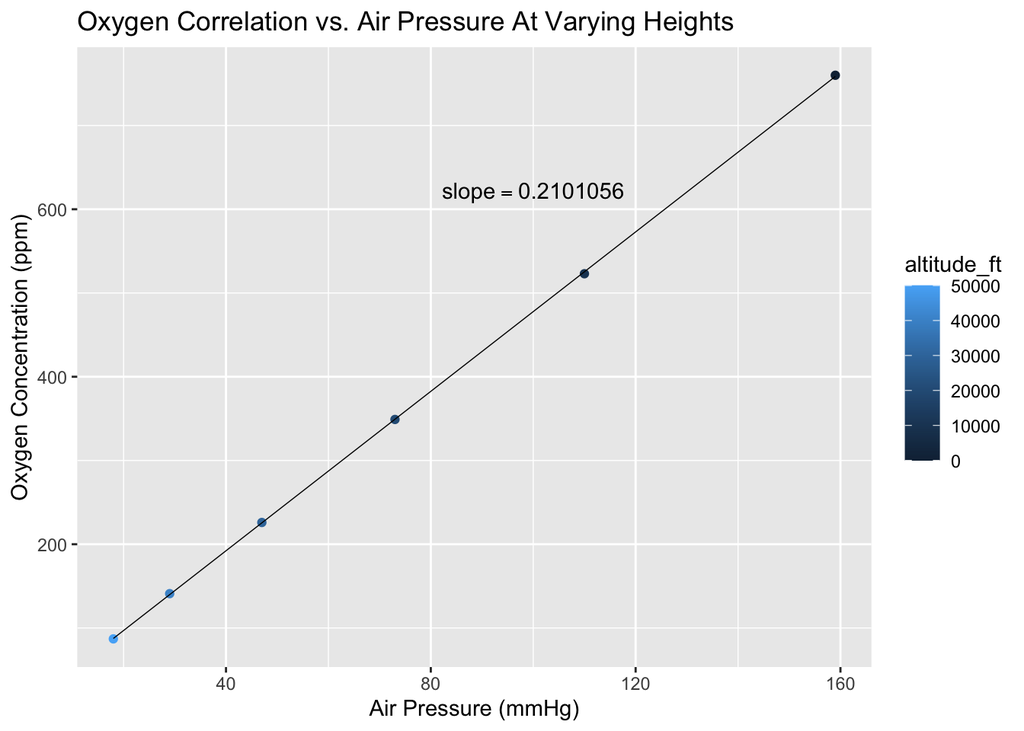

```r
ggplot(plt_df, aes(x=ppo2, y=air_press, color = altitude_ft)) +
  geom_point() +
  geom_smooth(method = "lm", se = FALSE, size=0.25, color='black') +
  labs(
    x = "Air Pressure (mmHg)",
    y = "Oxygen Concentration (ppm)",
    title = "Oxygen Correlation vs. Air Pressure At Varying Heights",
  ) +
  annotate("text",x=100,y=620,
           label=(paste0("slope==",coef(lm(plt_df$ppo2~plt_df$air_press))[2])),
           parse=TRUE)
```

It is clear in the plot above that there is an almost perfect correlation between the total air pressure and the air pressure due to oxygen as altitude increases. The fact that they are so perfectly correlated indicates that the concentration of oxygen does not change as altitude increases, which is consistent with what we know about our atmosphere. This also means that the slope of the line (which represents oxygen air pressure divided by total air pressure) should give the concentration of oxygen in our atmosphere. This is confirmed by the fact that the slope of the line is about 0.21, which is almost the exact proportion of oxygen atoms in our atmosphere.

# Conclusion

The work done above gives three examples of how unclean data sets can be tidied in order to answer hypothetical research questions. While the specifics involved in cleaning and analyzing each data set were different, it is important to note that many of the steps were similar, and the process in general is pretty much the same. These examples help to highlight that data cleaning is an essential part of any data science process.